# Question 4: LDA/QDA Analysis Skill

## (a) Define the skill

I created `lda-qda-stability/SKILL.md` to compare ordinary LDA and QDA using repeated cross-validation and a shuffled-label diagnostic. It is dataset-independent and requires a report of at most one printed page with a figure, table, and numerical results.

The skill is stored in this homework directory, outside automatically loaded skill folders. I supplied its path in an explicit request; it is not installed for automatic discovery.

The final skill file is **3725 bytes**, below the 5,000-byte limit.

## (b) Apply the skill

I explicitly invoked the skill using the following prompt:

> Explicitly use homework/week-07/lda-qda-stability/SKILL.md to analyze homework/week-07/data/saheart.csv. The response is chd; use all nine other variables as numerical predictors, with famhist coded Absent=1 and Present=2. Use R and seed 43207. Seek the best predictive performance among the ordinary LDA and QDA candidates allowed by the skill. Reserve a stratified 20% test set first, compare models using shared repeated five-fold CV, and perform the training-only shuffled-label diagnostic. Review and freeze selection using training/CV results before evaluating the selected model once on the reserved test set. Save code and a one-page report in homework/week-07/q4-output. Append the report, full skill, byte count, and this prompt to the Question 4 submission.

The seed was **43207**. Both candidates used all nine predictors with the Question 1 coding. The fixed stratified split reserved 93 observations for testing and left 369 for training. I compared the candidates using the same stratified five-fold partitions, repeated ten times. All means, covariances, and empirical priors were estimated within each fold’s training portion. No scaling, imputation, or embedding was needed.

For the placebo diagnostic, I shuffled only the training labels 50 times. Each shuffle repeated the same model-selection procedure, generating shared stratified folds for LDA and QDA and recording the lower mean CV error. This diagnostic was not used to tune the models.

## (c) Review and submit

Before evaluating the test set, I checked the coding, shared folds, fitting-sample priors, and training-only placebo procedure. All model fits completed without rank failures. LDA had the lower mean CV error, so I froze that selection. No skill revisions were needed. The training-only review is saved in `q4-output/training-review.txt`.

I then refitted LDA on all training observations and evaluated it once on the reserved test set. Subsequent report rendering reads saved results and does not refit or reevaluate the test set. The code blocks below are displayed for reproducibility rather than executed when this document renders.

### Final one-page analysis report

The following report is also provided as the one-page PDF `q4-output/q4-report.pdf`.

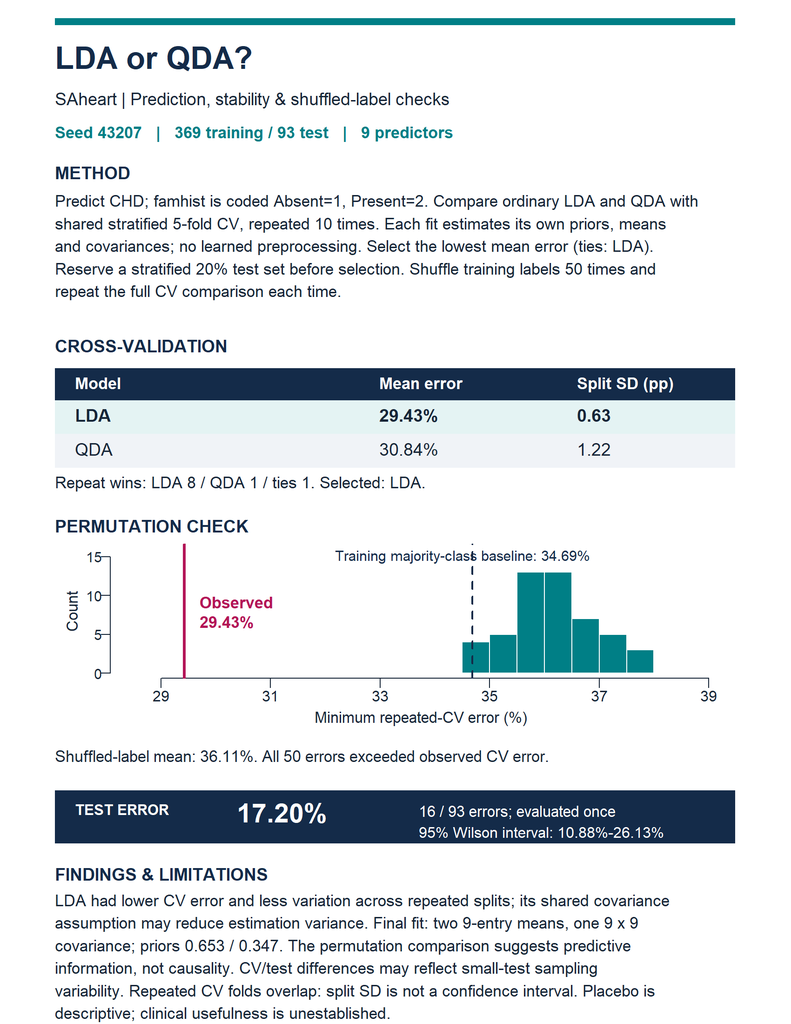

### Complete skill

```markdown
---
name: lda-qda-stability
description: Explicitly invoked classification analysis using repeated cross-validation and a shuffled-label diagnostic for LDA and QDA.
---

# LDA/QDA stability analysis

Load this file only when the user explicitly supplies its path and asks to use it. Keep it outside automatically discovered skill folders.

Accept the dataset, response, predictors, coding, seed, and output location separately. Seek the lowest cross-validated misclassification rate among ordinary LDA and QDA; do not claim optimality beyond these candidates. Use empirical class priors estimated from each fitting sample. Report covariance rank failures rather than silently regularizing or dropping predictors.

## Analysis

1. Check predictor coding, finite values, class counts, and matrix dimensions. If data require imputation or other preprocessing, define a reproducible procedure fitted only on the fitting observations within each fold. Do not change the user's predictor coding.
2. Set and report a seed. Reserve approximately 20% of each class as a test set before model comparison. Keep the test observations out of all diagnostics, revisions, and selection until the final evaluation.
3. On the remaining training data, run stratified five-fold cross-validation repeated ten times. Use identical folds for both candidates. Fit each model from scratch in each fold, including any preprocessing and empirical priors. For each repetition, calculate the error over all out-of-fold predictions. Report each model's mean error and the standard deviation across repetitions; the latter describes split sensitivity, not a confidence interval.
4. Select the candidate with the lowest mean repeated-CV error. Resolve exact ties in favor of LDA. Report how often each model wins a repetition, counting ties separately. Do not select the seed or folds to obtain a preferred winner.
5. As an auxiliary placebo diagnostic, shuffle only the training labels 50 times, preserving class counts. For each shuffle, repeat the entire same CV procedure for both models and record the lower mean error. Generate stratified folds from those shuffled labels and share them between candidates. Compare the observed minimum CV error with this distribution and the training majority-class error. Do not describe chance error as necessarily 50%, use placebo results for tuning, or infer causality. Treat this as a descriptive diagnostic, not proof of predictive validity.
6. Review code and training/CV results, finalize instructions, and record the selected candidate before accessing test outcomes. Refit it on all training data and evaluate once on the reserved test set. Report test sample size, error count, misclassification rate, and a binomial Wilson 95% interval. Do not compare other models on the test set or revise after seeing its error. Subsequent report rendering must reuse saved results.

## Report

Produce a readable English report of at most one printed letter/A4 page, and verify the exported page count. Include the target, sample sizes, seed, candidate models, repeated-CV and placebo procedure, a small table of both candidates' CV mean errors and split standard deviations, and one figure showing the placebo minimum-error distribution with the observed minimum marked. Give the selected model, numerical final-test results, and a short interpretation. Explain that repeated folds overlap, permutation results are diagnostic, and a small reserved test set limits precision. Include numerical fitting details such as predictor count and pooled or class covariance dimensions. Avoid causal or clinical claims. Put the complete skill, byte count, invocation prompt, and reproducible code outside this one-page report.
```

### Reproducible R analysis

From the `homework/week-07` directory, run `Rscript q4-analysis.R train`, review the training results and save the review, then run `Rscript q4-analysis.R test`. Run `Rscript q4-report.R` to export the report from saved final results. The analysis script stops if final results already exist, preventing accidental test reevaluation.

```r
library(MASS)
seed <- 43207
out <- "q4-output"
dir.create(out, showWarnings = FALSE)

folds <- function(y) {
  f <- integer(length(y))
  for (k in levels(y)) {
    ids <- which(y == k)
    f[ids] <- sample(rep(1:5, length.out = length(ids)))
  }
  f
}

cv_errors <- function(X, y, fold_sets) {
  t(sapply(fold_sets, function(f) {
    pred <- matrix(NA_character_, nrow(X), 2)
    for (j in 1:5) {
      fit_lda <- lda(X[f != j, , drop = FALSE], y[f != j])
      fit_qda <- qda(X[f != j, , drop = FALSE], y[f != j])
      pred[f == j, 1] <- as.character(predict(fit_lda, X[f == j, , drop = FALSE])$class)
      pred[f == j, 2] <- as.character(predict(fit_qda, X[f == j, , drop = FALSE])$class)
    }
    c(LDA = mean(pred[, 1] != y), QDA = mean(pred[, 2] != y))
  }))
}

train_analysis <- function() {
  if (file.exists(file.path(out, "final-results.rds"))) {
    stop("Final test results already exist; reuse them without revising selection.")
  }
  set.seed(seed)
  heart <- read.csv("data/saheart.csv")
  heart$famhist <- factor(heart$famhist, levels = c("Absent", "Present"))
  X <- data.matrix(heart[, names(heart) != "chd"])
  y <- factor(heart$chd)
  stopifnot(ncol(X) == 9, all(is.finite(X)), !anyNA(y))

  train_ids <- unlist(lapply(levels(y), function(k) {
    ids <- which(y == k)
    sample(ids, floor(0.8 * length(ids)))
  }))
  test_ids <- setdiff(seq_len(nrow(X)), train_ids)
  Xt <- X[train_ids, , drop = FALSE]
  yt <- y[train_ids]
  fold_sets <- replicate(10, folds(yt), simplify = FALSE)
  errors <- cv_errors(Xt, yt, fold_sets)
  avg <- colMeans(errors)
  selected <- names(avg)[which.min(avg)]
  wins <- c(LDA = sum(errors[, 1] < errors[, 2]),
            QDA = sum(errors[, 2] < errors[, 1]),
            Ties = sum(errors[, 1] == errors[, 2]))

  placebo <- replicate(50, {
    shuffled <- sample(yt)
    shuffled_folds <- replicate(10, folds(shuffled), simplify = FALSE)
    min(colMeans(cv_errors(Xt, shuffled, shuffled_folds)))
  })
  majority_error <- 1 - max(prop.table(table(yt)))
  summary <- data.frame(Model = names(avg), CV_error = avg,
                        Split_SD = apply(errors, 2, sd))
  write.csv(summary, file.path(out, "cv-summary.csv"), row.names = FALSE)
  write.csv(data.frame(errors), file.path(out, "cv-repetitions.csv"), row.names = FALSE)
  write.csv(data.frame(Error = placebo), file.path(out, "placebo-errors.csv"), row.names = FALSE)
  results <- list(seed = seed, X = X, y = y, train_ids = train_ids,
                  test_ids = test_ids, fold_sets = fold_sets, errors = errors,
                  summary = summary, selected = selected, wins = wins,
                  placebo = placebo, majority_error = majority_error)
  saveRDS(results, file.path(out, "training-results.rds"))
  print(summary)
  print(wins)
  cat("Selected:", selected, "\nTraining:", length(train_ids),
      " Test reserved:", length(test_ids), "\nMajority error:", majority_error,
      "\nPlacebo mean:", mean(placebo), "\n")
}

test_analysis <- function() {
  if (file.exists(file.path(out, "final-results.rds"))) {
    stop("Test was already evaluated. Render from saved results.")
  }
  r <- readRDS(file.path(out, "training-results.rds"))
  stopifnot(file.exists(file.path(out, "training-review.txt")))
  fit_fun <- if (r$selected == "LDA") lda else qda
  fit <- fit_fun(r$X[r$train_ids, , drop = FALSE], r$y[r$train_ids])
  pred <- predict(fit, r$X[r$test_ids, , drop = FALSE])$class
  r$confusion <- table(Observed = r$y[r$test_ids], Predicted = pred)
  r$test_errors <- sum(pred != r$y[r$test_ids])
  n <- length(r$test_ids)
  p <- r$test_errors / n
  z <- qnorm(0.975)
  center <- (p + z^2 / (2 * n)) / (1 + z^2 / n)
  half <- z * sqrt(p * (1 - p) / n + z^2 / (4 * n^2)) / (1 + z^2 / n)
  r$test_error <- p
  r$interval <- c(center - half, center + half)
  r$fit <- fit
  saveRDS(r, file.path(out, "final-results.rds"))
  print(r$confusion)
  cat("Selected:", r$selected, " Test error:", p,
      " Wilson interval:", r$interval, "\n")
}

args <- commandArgs(trailingOnly = TRUE)
if (length(args) && args[1] == "train") train_analysis()
if (length(args) && args[1] == "test") test_analysis()
```